# Henry IV Analysis

### Summary Stats

```python
print('Shakespeare:')
shakespearedf.describe()
```

```
Shakespeare:
```

|  | Avg. Word Length | Avg. Sent. Complexity | Type Token Ratio | Hapax Leg. Ratio |
| --- | --- | --- | --- | --- |
| count | 8.000000 | 8.000000 | 8.000000 | 8.000000 |
| mean | 4.597944 | 5.394883 | 0.238077 | 0.168536 |
| std | 0.349365 | 1.298616 | 0.068148 | 0.066094 |
| min | 4.093800 | 3.311388 | 0.149152 | 0.083385 |
| 25% | 4.249985 | 4.559833 | 0.165916 | 0.095650 |
| 50% | 4.695337 | 5.454999 | 0.271855 | 0.204811 |
| 75% | 4.932346 | 6.417246 | 0.282113 | 0.212810 |
| max | 4.934909 | 7.050725 | 0.320169 | 0.242025 |

```python
print('Marlowe:')
marlowedf.describe()
```

```
Marlowe:
```

|  | Avg. Word Length | Avg. Sent. Complexity | Type Token Ratio | Hapax Leg. Ratio |
| --- | --- | --- | --- | --- |
| count | 4.000000 | 4.000000 | 4.000000 | 4.000000 |
| mean | 4.700647 | 5.329639 | 0.218193 | 0.142091 |
| std | 0.242206 | 1.405047 | 0.063930 | 0.062895 |
| min | 4.401469 | 3.866527 | 0.181528 | 0.106473 |
| 25% | 4.609966 | 4.697350 | 0.184506 | 0.110311 |
| 50% | 4.704267 | 5.106318 | 0.188685 | 0.112788 |
| 75% | 4.794948 | 5.738607 | 0.222373 | 0.144568 |
| max | 4.992583 | 7.239394 | 0.313875 | 0.236317 |

**Notes:**

### Sample Plots

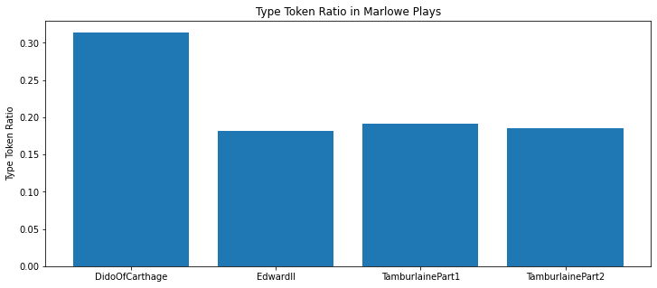

```python
#barplot of TTR, Marlowe
fig = plt.figure(figsize=(12,5))

plt.bar(marlowedf.index, marlowedf['Type Token Ratio'])
plt.title('Type Token Ratio in Marlowe Plays')
plt.ylabel('Type Token Ratio')
plt.show()
```

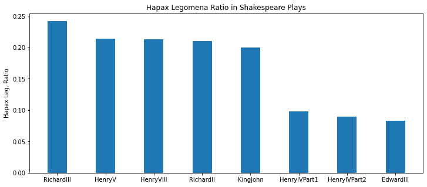

```python
#Hapax Legomena Ratio in Shakespeare Plays
fig = plt.figure(figsize=(12,5))

df_sorted = shakespearedf.sort_values('Hapax Leg. Ratio', ascending=False)

plt.bar(shakespearedf.index, df_sorted['Hapax Leg. Ratio'], width=0.4)
plt.title('Hapax Legomena Ratio in Shakespeare Plays')
plt.ylabel('Hapax Leg. Ratio')
plt.show()
```

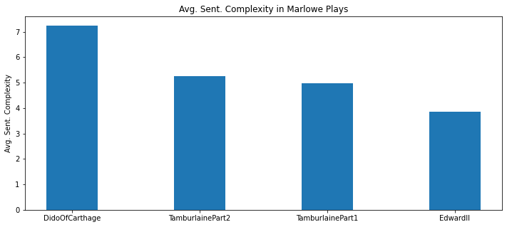

```python
#Sentence Complexity in Marlowe
fig = plt.figure(figsize=(12,5))

df_sorted = marlowedf.sort_values('Avg. Sent. Complexity', ascending=False)

plt.bar(df_sorted.index, df_sorted['Avg. Sent. Complexity'], width=0.4)
plt.title('Avg. Sent. Complexity in Marlowe Plays')
plt.ylabel('Avg. Sent. Complexity')
plt.show()
```

## Section 4 - Compare fingerprints, authorship analysis

**Choosing a comparison metric:** In the analysis that Pranav, Sid, and myself performed on *The Passionate Pilgrim*, we used the geometric mean of the proportional error on each attribute and attributed the piece to the author whose fingerprint minimized this error function.

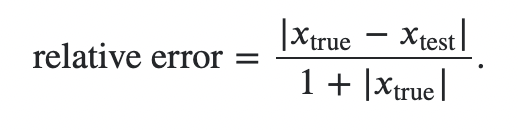

```python
#geometric mean function
def geom_mean(author_print, work_print):
    error_list = []

    #compile errors at each attribute
    for i in range(len(author_print)):
        author = author_print[i]
        work = work_print[i]

        #Percent error calculation ((experimental-theoretical)/theoretical), with a slight modification
        if not(author == 0.0 or work == 0.0):
            perc_error = abs((work-author)/author)*100
            error_list.append(perc_error)

    #calculate geometric mean
    n = len(error_list)
    prod = np.prod(error_list)

    return prod**(1/n)
```

```python
#Calculate error lists
shakes_error = []
marlowe_error = []

parts = ['Part1', 'Part2', 'Part3']
for part in parts:
    henryVI = HenryVIdf.loc[part]
    shakes_error.append(geom_mean(shakes_total_print, henryVI))

for part in parts:
    henryVI = HenryVIdf.loc[part]
    marlowe_error.append(geom_mean(marlowe_total_print, henryVI))
```

```python
#Create error df
df_dict = {"shakespeare": shakes_error, "marlowe": marlowe_error}
error_df = pd.DataFrame(df_dict)
error_df.rename(index={0: "Part 1", 1: "Part 2", 2: "Part 3"}, inplace=True)
error_df.head()
```

|  | shakespeare | marlowe |
| --- | --- | --- |
| Part 1 | 10.133155 | 16.658010 |
| Part 2 | 10.589262 | 12.915810 |
| Part 3 | 10.735968 | 5.899749 |

### Error Visualization

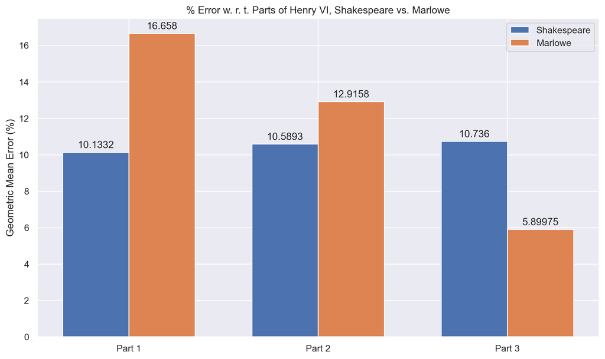

```python
#Error Visualization
labels = error_df.index

x = np.arange(len(labels))  # the label locations
width = 0.35  # the width of the bars

#set figure size
fig, ax = plt.subplots(figsize=(12,7))

#create side-by-side bar graph
rects1 = ax.bar(x - width/2, error_df['shakespeare'], width, label='Shakespeare')
rects2 = ax.bar(x + width/2, error_df['marlowe'], width, label='Marlowe')

# Add some text for labels, title and custom x-axis tick labels, etc.
ax.set_ylabel('Geometric Mean Error (%)')
ax.set_title('% Error w. r. t. Parts of Henry VI, Shakespeare vs. Marlowe')
ax.set_xticks(x, labels)
ax.legend()

#add labels
ax.bar_label(rects1, padding=3)
ax.bar_label(rects2, padding=3)

#set figure image quality
plt.rcParams['figure.dpi'] = 300
plt.rcParams['savefig.dpi'] = 300

plt.show()
```

## Conclusions:

According to my analysis, there does not seem to be any particular evidence to suggest that Marlowe was responsible for writing any of the parts of *King Henry VI*. The error between the stylistic profile of Shakespeare's historiesand each part of *Henry VI* was similar to the error between Marlowe's profile and the same play. On the margins, Part 1 and 2 were more closely linked to Shakespeare's profile and Part 3 to Marlowe's. But, none of the differences were so large so as to suggest differing authorship.

## 5. Comparing individual plays

Create an error matrix of each of Shakespeare's plays compared to each other. Which are most similar? Which are least similar?

```python
#add Henry VI plays back to Shakespeare matrix
newdf = pd.concat([shakespearedf, HenryVIdf])
newdf = newdf.rename(index={"Part1": "HenryVIPart1", "Part2": "HenryVIPart2", "Part3": "HenryVIPart3"})
#Compose error matrix - shakespeare
shakes_plays = newdf.index
error_matrix = []

for i in range(len(shakes_plays)):
    new_list = []
    for j in range(len(shakes_plays)):
        new_list.append(geom_mean(newdf.loc[shakes_plays[i]], newdf.loc[shakes_plays[j]]))
    error_matrix.append(new_list)
```

```python
error_dict = {}
for i in range(len(error_matrix)):
    error_dict[shakes_plays[i]] = error_matrix[i]

error_matrix_df = pd.DataFrame(error_dict)
error_matrix_df.rename(index={0: 'RichardIII', 1: 'HenryV', 2: 'HenryVIII', 3: 'RichardII', 4: 'KingJohn', 5: 'HenryIVPart1', 6: 'HenryIVPart2', 7: 'EdwardIII', 8: 'HenryVIPart1', 9: 'HenryVIPart1', 10: 'HenryVIPart1'}, inplace=True)
error_matrix_df
```

|  | RichardIII | HenryV | HenryVIII | RichardII | KingJohn | HenryIVPart1 | HenryIVPart2 | EdwardIII | HenryVIPart1 | HenryVIPart2 | HenryVIPart3 |
| --- | --- | --- | --- | --- | --- | --- | --- | --- | --- | --- | --- |
| RichardIII | 0.000000 | 4.846526 | 56.046571 | 1.060098 | 45.705179 | 67.810080 | 1.769294 | 3.043285 | 47.295176 | 54.804197 | 62.931626 |
| HenryV | 4.618909 | 0.000000 | 46.559168 | 8.806400 | 37.394170 | 58.145076 | 1.792966 | 11.357555 | 37.305316 | 45.345912 | 52.079780 |
| HenryVIII | 33.252316 | 28.984727 | 0.000000 | 19.875078 | 3.055073 | 7.802668 | 30.050375 | 36.703355 | 8.873344 | 2.158103 | 5.172499 |
| RichardII | 0.981085 | 8.551652 | 31.002483 | 0.000000 | 24.826276 | 55.129296 | 5.616765 | 3.008078 | 33.080237 | 34.517547 | 46.026960 |
| KingJohn | 29.631319 | 25.437863 | 3.338369 | 17.391486 | 0.000000 | 10.715323 | 26.710558 | 33.607796 | 3.785544 | 4.772052 | 11.005693 |
| HenryIVPart1 | 38.144589 | 34.319645 | 7.397909 | 33.508938 | 9.297333 | 0.000000 | 35.204449 | 41.351459 | 9.873230 | 3.765472 | 10.447161 |
| HenryIVPart2 | 1.734928 | 1.844781 | 49.665935 | 5.951238 | 40.399776 | 61.367782 | 0.000000 | 9.443504 | 39.618933 | 48.287908 | 54.968358 |
| EdwardIII | 3.327117 | 13.028709 | 67.632947 | 3.553481 | 56.673476 | 80.366960 | 10.528755 | 0.000000 | 57.536090 | 66.147971 | 74.619449 |
| HenryVIPart1 | 29.843092 | 24.699539 | 9.437163 | 22.554599 | 3.684425 | 11.075097 | 25.494598 | 33.207939 | 0.000000 | 6.848994 | 8.575148 |
| HenryVIPart1 | 32.918574 | 28.579623 | 2.184874 | 22.403025 | 4.421268 | 4.020758 | 29.579037 | 36.342796 | 6.519691 | 0.000000 | 5.643304 |
| HenryVIPart1 | 35.204074 | 30.569214 | 4.876987 | 27.821196 | 9.496330 | 10.389235 | 31.358492 | 38.181292 | 7.602189 | 5.255695 | 0.000000 |

```python
#gets smallest non-zero value (since the error between the play and itself is 0)
def small_non_zero(input_list):
    smallest = max(input_list)
    for i in range(len(input_list)):
        if input_list[i] != 0 and input_list[i] < smallest:
            smallest = input_list[i]
    return smallest

# prints most similar/least similar
for play in shakes_plays:
    error_list = error_matrix_df[play].to_list()

    least_sim = shakes_plays[error_list.index(max(error_list))]
    most_sim = shakes_plays[error_list.index(small_non_zero(error_list))]

    print(play + " is most similar to " + most_sim + " and least similar to " + least_sim)
```

```
RichardIII is most similar to RichardII and least similar to HenryIVPart1
HenryV is most similar to HenryIVPart2 and least similar to HenryIVPart1
HenryVIII is most similar to HenryVIPart2 and least similar to EdwardIII
RichardII is most similar to RichardIII and least similar to HenryIVPart1
KingJohn is most similar to HenryVIII and least similar to EdwardIII
HenryIVPart1 is most similar to HenryVIPart2 and least similar to EdwardIII
HenryIVPart2 is most similar to RichardIII and least similar to HenryIVPart1
EdwardIII is most similar to RichardII and least similar to HenryIVPart1
HenryVIPart1 is most similar to KingJohn and least similar to EdwardIII
HenryVIPart2 is most similar to HenryVIII and least similar to EdwardIII
HenryVIPart3 is most similar to HenryVIII and least similar to EdwardIII
```

```
[Text(0.5, 1.0, "Stylistic Difference, Shakespeare's Histories (%)")]
```

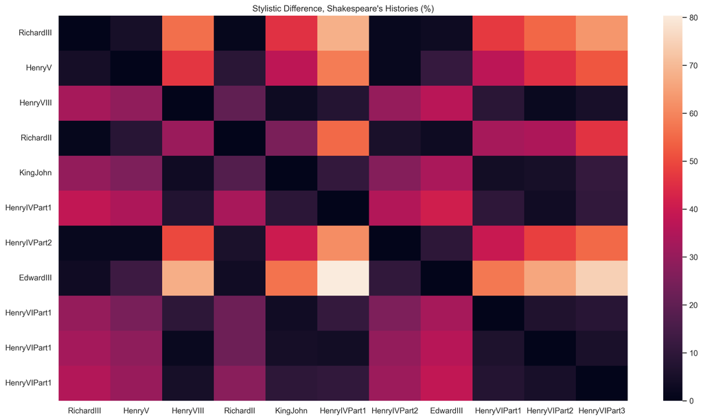

```python
#Seaborn heatmap
# %pip install seaborn
import seaborn as sns
sns.set(rc = {'figure.figsize':(18,10), "figure.dpi":300, 'savefig.dpi':300})
sns.heatmap(error_matrix_df).set(title="Stylistic Difference, Shakespeare's Histories (%)")
```